**Prediction Prep**

In order to have data shaped the way I wanted it in order to both **test a regression**, and then **apply it**, I created 2 different *R scripts*.  
Here is what I did for each:

For Regression Testing

- No **NA** values
- Only values with **SWE** > 0
- **Snow depth** > 0
- No 5:1 or 10:1 snow ratios
- No values over 50 inches depth where ratio > 5

For Prediction Application

- Depth = 0 when SWE = 0
- Separate NA depth rows from valid depth
- To NA –> 5:1 or 10:1 snow ratios
- To NA –> values over 50 inches depth where ratio > 5

Some explanation on what I did  
I took only included rows where **SWE > 0** because when it is 0, we already know the depth is 0.  
I filtered out the ratios where **depth = 5,10** because I supposed they are not the real values.  
I don’t want any values where the **snow ratio > 5** past 50 inches of depth because it is improbable. It’s probably when the **depth < 50** because for early/late season snowfalls, when the snowpack is only what 1 storm has left, the **snow ratio** tends to be a lot higher, but deceases over time when snow from newer storms compact snow from prior storms.  
*That is shown in the graphic below.*

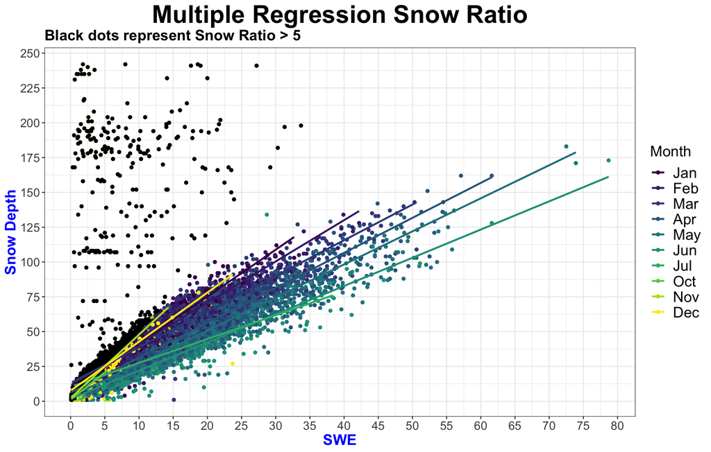

In effort to fit the regression to the values that make the most sense possible, I made the arbitrary decision stated above, and cut out values past 50 **depth** with a **ratio** more than 5.

All of my efforts to prepare for applying the regression were to separate the data into 2 sets: for creating the regression *(once we proved it works)*, and to apply it towards who’s **snow depth** values are **NA**.